# Salary Caps: Are they Effective?

Author

Phebe Chen and Marshall Roll

Published

April 24, 2024

In the United States, many competitive professional sports leagues employ some sort of salary cap, which essentially sets a maximum amount that each team can spend on all its players’ salaries. This policy is designed to maintain overall competitiveness across all teams in the league, ensuring that teams with wealthier owners are unable to “runaway” from the other teams in the league by signing the best players to high-value contracts. It also helps to keep overall costs low, which can help keep transfers and trades between teams affordable and keep operational costs relatively stable and affordable for all teams across the league. However, opponents of salary caps point to its harmful effects in terms of collective bargaining, when players feel they should receive increased wages for strong performances but teams are unable to do so given the constraints of the salary cap. As such, several major labor lockouts and strikes by players’ unions have occurred as a result of salary cap policies.

**So, how do salary caps work across different leagues?** We chose to focus on four American sports leagues: National Football League (NFL), National Hockey League (NHL), National Basketball Association (NBA), and Major League Baseball (MLB), excluding leagues with lower total spending such as Major League Soccer (MLS) and the Canadian Football League (CFL) even though they also employ salary cap policies. Each of these leagues has slightly different regulations surrounding the salary cap, so comparing them can show how varied policies lead to different effects both in terms of player contract value and overall performance of teams in each league. The regulations of each league are outlined in the image below.

[figure not shown]

Salary Cap Rules in Selected Sports Leagues

The NFL and NHL have hard salary caps, meaning that there are no exceptions for teams to go above the established maximum amounts. There are also established minimum amounts, to prevent ownership groups from assembling extremely poor and uncompetitive teams. These regulations stand in contrast to the NBA and MLB. The former employs a soft salary cap–there is a maximum amount that can be spent on salaries, but there are several exceptions that allow teams to exceed that value. The MLB, on the other hand, has no salary cap and only employs a luxury tax. Thus, teams could theoretically spend as much or as little as they want on their payroll.

So let’s dive a little deeper into the salary data and see **how do these different types of salary cap regulations affect salaries across leagues?** To look at a distribution of salary ranges across the four leagues, we’ll use average annual value (AAV) of the contracts, which is defined as the total value of the contract divided by how many years long it is. We use AAV instead of base annual salary because many contracts come with large up-front signing bonuses, so it is more accurate to divide the total cost of the contract over its entire length.

#### **Sport-specific considerations drive salary distributions in conjunction with league salary cap regulations**

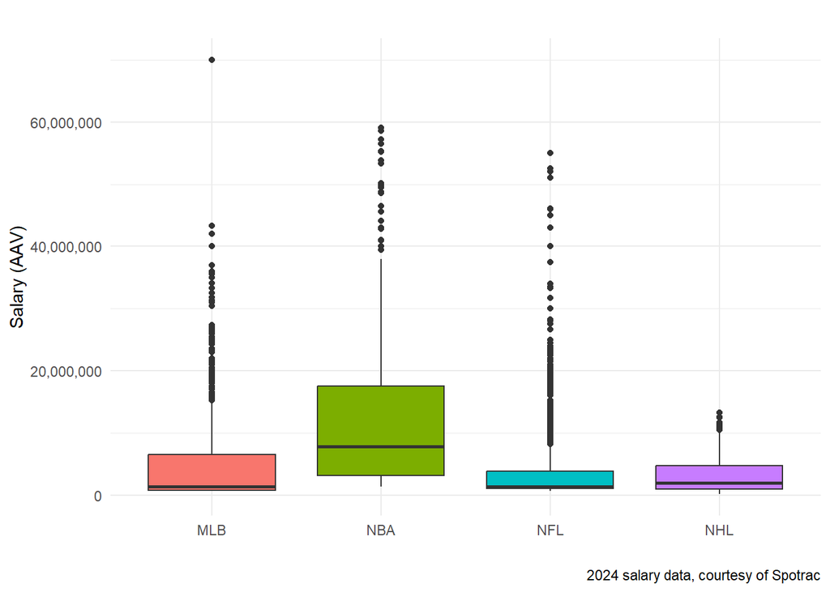

We see that the distribution of AAV is different in each league–this can be explained by a combination of both the specific needs in each sport and the salary cap regulations. For example, the NFL has the lowest median salary but many high-lying outliers. This is because in the NFL, a team can have up to 53 players on their roster. Teams are more likely to spend big on more “important” positions, like starting quarterbacks and wide receivers, and spend less on the many backup players that are required to maintain a full roster while staying within the limits of the salary cap. This may explain why there are so many outliers relative to the fairly low median.

In the NBA, on the other hand, the median is relatively high while there are a number of high outliers. This may be because NBA rosters only have 15 players, which means that teams can spend more on individual salaries relative to other leagues, which have larger roster sizes. Additionally, the soft salary cap allows NBA teams to opt to spend more on star players, which may explain the large number of high-lying outliers.

Yet another distribution can be seen in the NHL, where there are very few outliers relative to other leagues–this is likely due to a combination of the fairly low hard salary cap and the similarity in importance of players from different positions in hockey. Unlike football or baseball, where pitchers and quarterbacks have outsized importance on the game, players in hockey must all be of similar skill level as they frequently rotate in and out of gameplay, utilizing the full 23-player roster.

We can see that salary cap regulations do have some effect on contract value and structure, but **how do these differences play out on the overall levels of competitiveness between the leagues?** If, in leagues without a salary cap, overall competitiveness is diminished, we might expect to see a select number of teams that spend big dominating. To measure this, we can look at the relationship between teams’ playoff appearances and total spending on salaries. Then, we can compare this across leagues to determine if there is a pattern connected to the stringency of salary cap regulations.

#### **Playoff appearances are not equally dispersed across all leagues.**

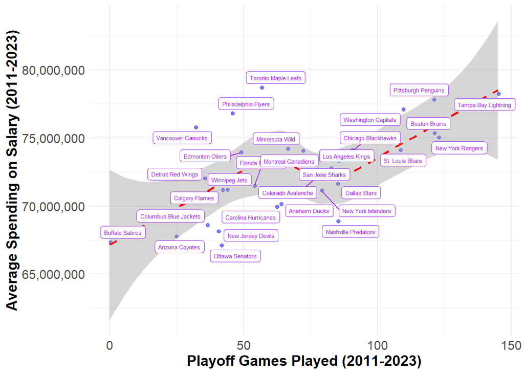

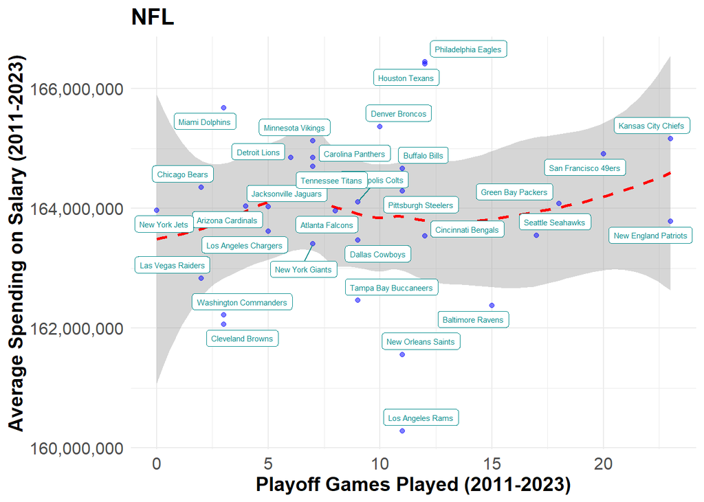

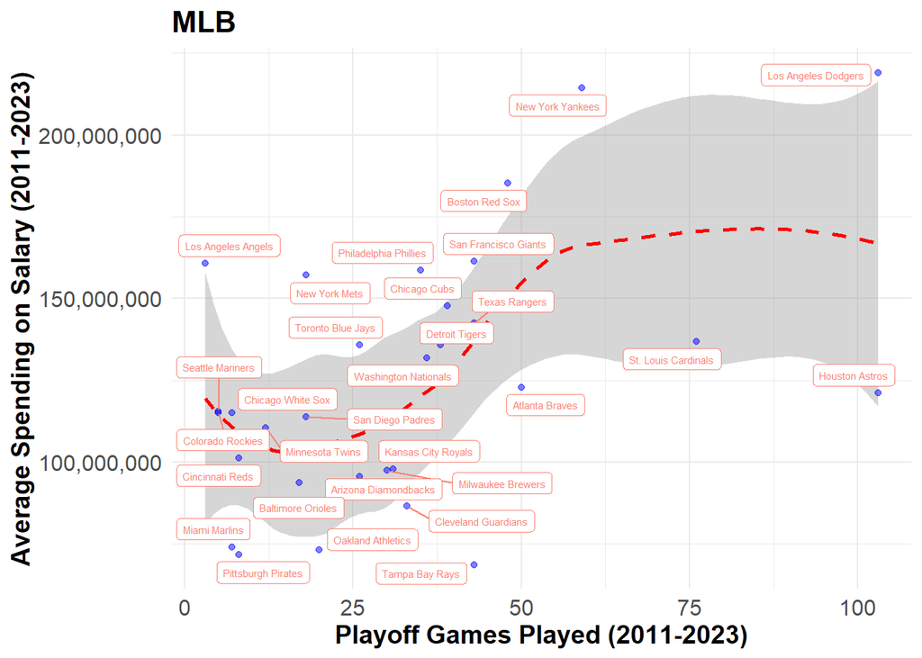

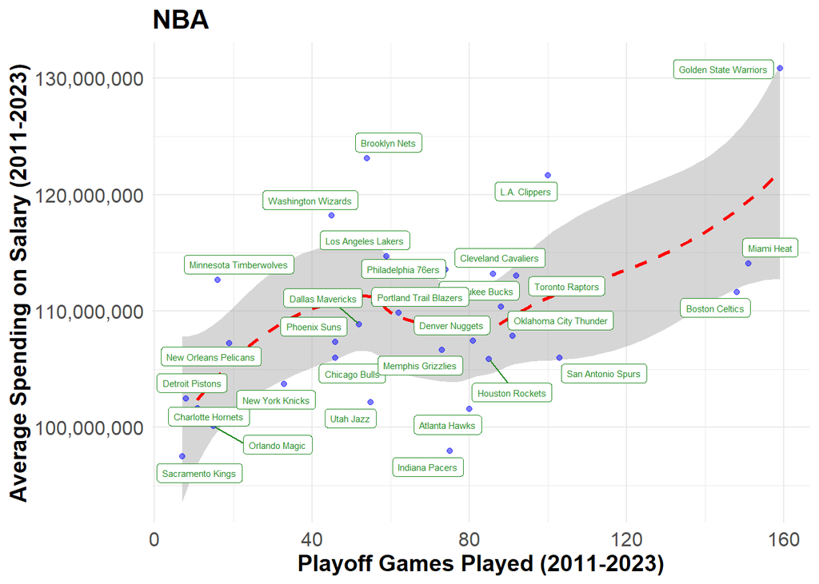

Although success is ultimately determined through the playoffs, these one-off games and series are not necessarily fully representative of a team’s true performance over the course of a season. Thus, it is also useful to look at trends within the course of the regular season.

#### **Patterns observed in the playoffs tend to be mirrored in the regular season**

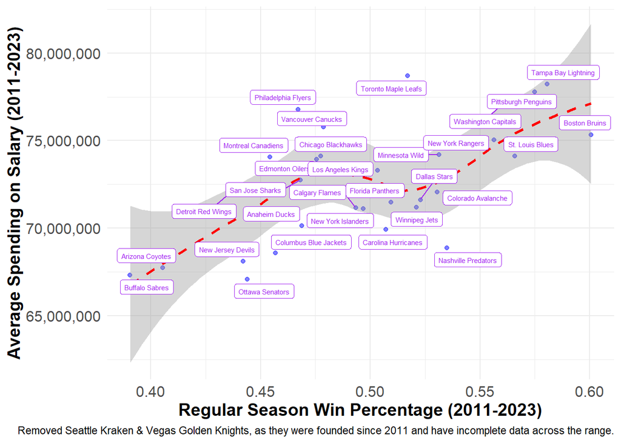

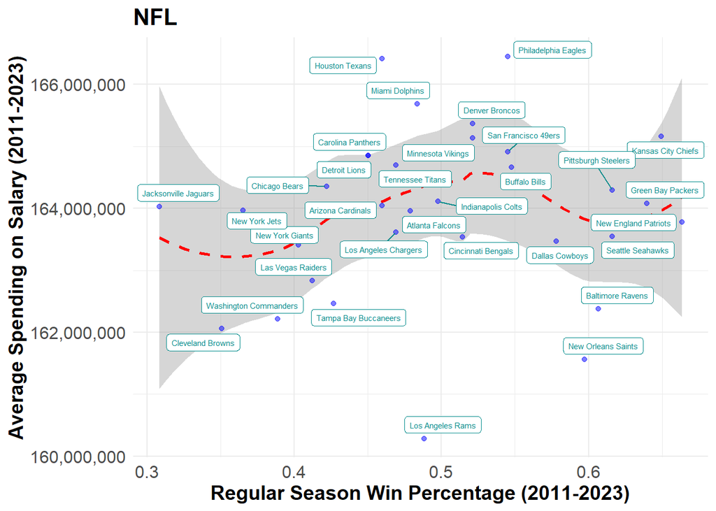

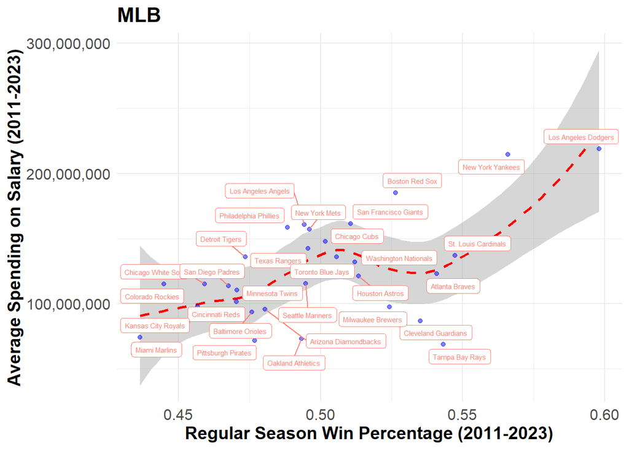

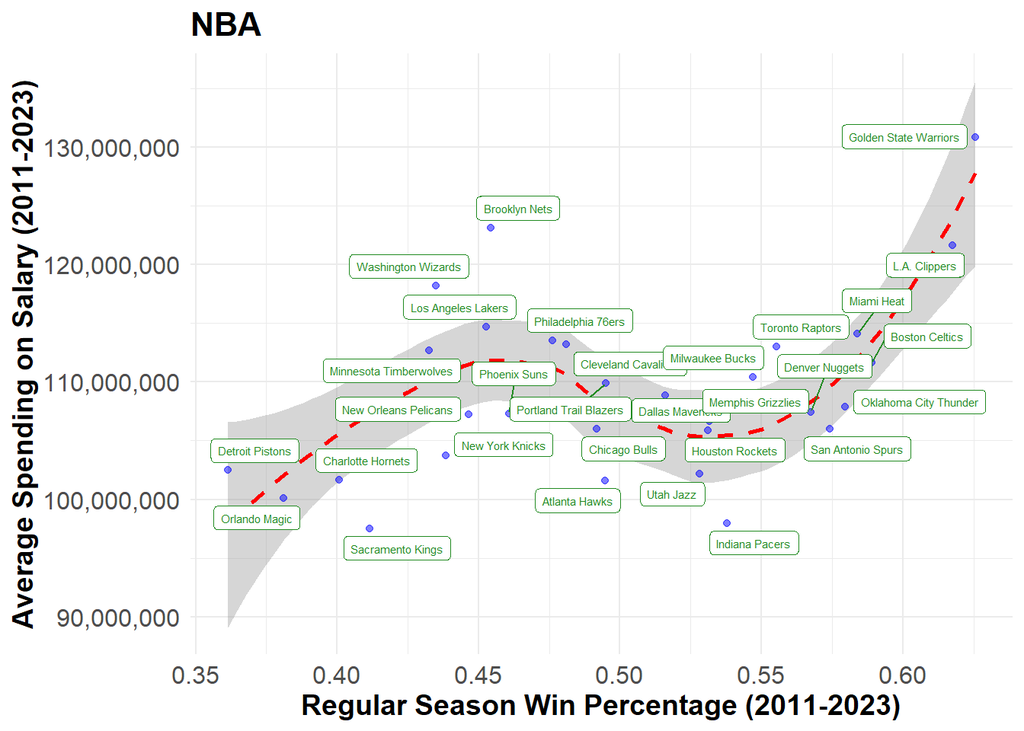

The trends in the above figures tend to mirror those seen in the playoffs–in the NHL, there seems to be a somewhat linear association between spending and performance; in the NFL, there seems to be relatively little association, and in the MLB and NBA, a small set of teams that spend highly seem to perform highly, while the remainder of the teams seem to be clustered together fairly tightly.

**So what can we conclude about salary caps?** Well, it seems to be a fairly mixed bag. Both the NHL and NFL do have hard salary caps but we see different results in how these play out both in terms of player contract values and performances. In the NHL, there don’t tend to be many extremely high value contracts, and there seems to be a general trend that the more that is invested in a team, the better they perform. This is perhaps the most straightforward league to understand out of all those selected.

In the NFL, however, we see that there are a number of high outlying contracts with a relatively low median salary, which makes sense given the context of the sport. We also see that, in terms of both regular season and playoff performance, the NFL is very unpredictable, with no “super team” that invests heavily outperforming others in the period. This indicates that the NFL has strong competitive balance, and is perhaps the best model for a league where any one team can achieve success in a given season. However, it is important to note that in the NFL season and postseason there are significantly fewer games than in any of the other three leagues, which could cause this dispersion, as each individual game holds a greater significance, so a “blip” in a season would have a much bigger effect than in other leagues.